# Bias and fairness

Computer-Aided Medical Diagnostics, MPA-PRM (from 2027/28 Applied AI in Life Sciences, MPA-AUI)

Jiří Chmelík

Department of Biomedical Engineering · FEEC, Brno University of Technology

2026-11-05

## Learning goals

Find where bias gets in

Sampling, labels, measurement, history, aggregation — documented cases from oximeters, kidney equations, care algorithms and chest X-rays.

Measure it

Selection rate, TPR, FPR, PPV and calibration per group — and how little a small subgroup can tell you.

Choose a definition

Demographic parity, equal opportunity, equalized odds, calibration — why you cannot have them all, and what each one misses.

Mitigate — and see the price

Reweighing, a training constraint, per-group thresholds — on a held-out split: what gets fixed, and who pays for it.

TPR — true positive rate (sensitivity) · FPR — false positive rate · PPV — positive predictive value (precision)

## Race was never a feature

Race was never an input of the algorithm.  
It did not need to be.

Obermeyer, Powers, Vogeli, Mullainathan (2019), *Science* — the lecture comes back to it in a few slides.

## 1 · Where bias comes from

> The data faithfully reflect a world that was already unfair.

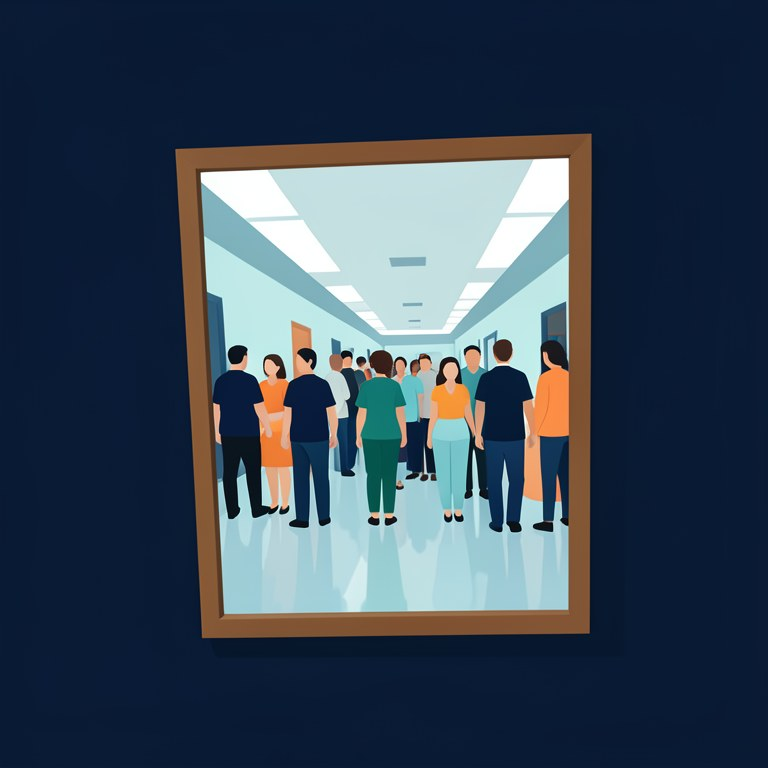

Illustrative image, generated with FLUX.2 [klein] 4B

## The model you already explained

Heart Disease · XGBoost

303 patients, 13 clinical features, disease yes/no — the model of *Explainability and interpretability of models*, the same split, accuracy 0.868. SHAP told us **why one patient** was flagged.

Today’s question is different: does the model treat every **group** of patients the same way?

In these data 97 patients are women (25.8 % with the disease) and 206 are men (55.3 %).

XGBoost — eXtreme Gradient Boosting · SHAP — SHapley Additive exPlanations

## Five ways bias gets in

Sampling

the training population is not the population the model is used on

Label

the target is itself a biased proxy for what you care about

Measurement

the instrument is less accurate for some groups

Historical

the data reflect a world that was already unequal

Aggregation

one global model hides a relationship that differs by subgroup

Close to Suresh, Guttag (2021), [arXiv:1901.10002](https://arxiv.org/abs/1901.10002) — they call sampling bias *representation* bias and count a proxy label as *measurement* bias

## Pulse oximetry — measurement bias

- A pulse oximeter estimates blood oxygen **through the skin** — an optical measurement.
- In patients with darker skin it **overestimates** the true saturation more often.
- **Occult hypoxemia** — arterial saturation below 88 % while the oximeter reads 92–96 % — about **three times as often** in Black patients.

[figure not shown]

Sjoding, Dickson, Iwashyna, Gay, Valley (2020), *Racial Bias in Pulse Oximetry Measurement*, [NEJM 383:2477](https://www.nejm.org/doi/full/10.1056/NEJMc2029240) — University of Michigan cohort, unadjusted

SaO₂ — arterial oxygen saturation, from a blood gas · CI — confidence interval

## Race in a clinical equation

- The **eGFR** of every lab report: a readable formula of creatinine, age and sex.
- CKD-EPI 2009 multiplied it by **1.159** if the patient was recorded as Black.
- Same blood test, a **16 % better** kidney on paper — later referral, later transplant listing.
- 2021: refitted **without race**.

[figure not shown]

Levey et al. (2009), *Ann Intern Med* 150:604 · Inker et al. (2021), *New Creatinine- and Cystatin C–Based Equations to Estimate GFR without Race*, [NEJM 385:1737](https://www.nejm.org/doi/full/10.1056/NEJMoa2102953)

eGFR — estimated glomerular filtration rate · CKD-EPI — Chronic Kidney Disease Epidemiology Collaboration

## No race feature — so how?

The algorithm never saw race.  
How could it end up racially biased?

Think for a minute, then tell your neighbour.

## Obermeyer et al. (2019) — label bias

A commercial algorithm, used for **millions** of US patients, ranked who should get extra care management.

**predicted**

future healthcare cost

≈

**read as**

“is sicker”

but

**history**

less spent on Black patients at equal illness

→

**result**

Black patients had to be sicker for the same score

**Published effect:** removing the bias would have raised the share of Black patients among those selected for extra help from **17.7 % to 46.5 %**.

Obermeyer, Powers, Vogeli, Mullainathan (2019), *Science* 366:447, [doi:10.1126/science.aax2342](https://www.science.org/doi/10.1126/science.aax2342)

## The mechanism, simulated

[figure not shown]

Synthetic data — the study’s data are not public.

## HAM10000 — sampling bias

- A widely used dermatology data set: 10 015 dermoscopic images of skin lesions, collected in **Austria and Australia**.
- It records age, sex and body site — **not skin type**. Its skin-type mix is unknown and, given where it was collected, very likely light.
- A classifier trained on it can generalize **worse to darker skin** — and without the metadata no audit can even measure how much.
- The remedy is boring and essential: document who is in a data set — and who is not (the STANDING Together recommendations).

**Sampling bias you cannot audit:** a subgroup that is missing from the data is also missing from the fairness report.

Tschandl, Rosendahl, Kittler (2018), *The HAM10000 dataset*, [Scientific Data 5:180161](https://www.nature.com/articles/sdata2018161) · Alderman et al. (2025), *STANDING Together consensus recommendations*, Lancet Digit Health 7:e64

## Who is in the training data?

[figure not shown]

The same 140 training patients, a different mix: with no women in training the women’s accuracy is **0.708**, with half of them women **0.875**. The men’s curve barely moves.

Our model, simulated after Larrazabal et al. (2020), *Gender imbalance in medical imaging datasets produces biased classifiers*, [PNAS 117:12592](https://www.pnas.org/doi/10.1073/pnas.1919012117) — they did it with chest X-ray classifiers

AUC — area under the ROC (receiver operating characteristic) curve

## Chest X-ray models underdiagnose

- Classifiers trained on three large public chest X-ray data sets — the kind of network the explainability lab trained on PneumoniaMNIST.
- The audited error: **“no finding”** predicted for a patient whose X-ray had a finding — a missed diagnosis.
- Missed more often in **female** patients, **patients under 20**, **Black** and **Hispanic** patients and those on **Medicaid** (US public insurance for low incomes).
- Worst at the **intersections** — e.g. Hispanic women.

An under-served group gets **“no finding”** more often — and a model that says “healthy” sends no one for a second look.

Seyyed-Kalantari, Zhang, McDermott, Chen, Ghassemi (2021), *Underdiagnosis bias of artificial intelligence algorithms applied to chest radiographs in under-served patient populations*, [Nat Med 27:2176](https://www.nature.com/articles/s41591-021-01595-0)

## A network can see race in an X-ray

- Deep networks predicted **self-reported race** from X-rays — chest, cervical spine, hand — with an AUC of **0.91–0.99**, also on external data sets.
- Radiologists cannot do this — and the authors could not find **what** the network uses: not body mass, not the distribution of disease, and it survived heavy filtering and degradation of the images.
- So “the model never saw race” means little: the attribute is **in the pixels**.

Removing a column does not remove the information. The same holds for our tabular model — block 3 measures it.

Gichoya et al. (2022), *AI recognition of patient race in medical imaging: a modelling study*, Lancet Digit Health 4:e406

AI — artificial intelligence

## 2 · What “fair” means

> Pick the definition before you look at the numbers.

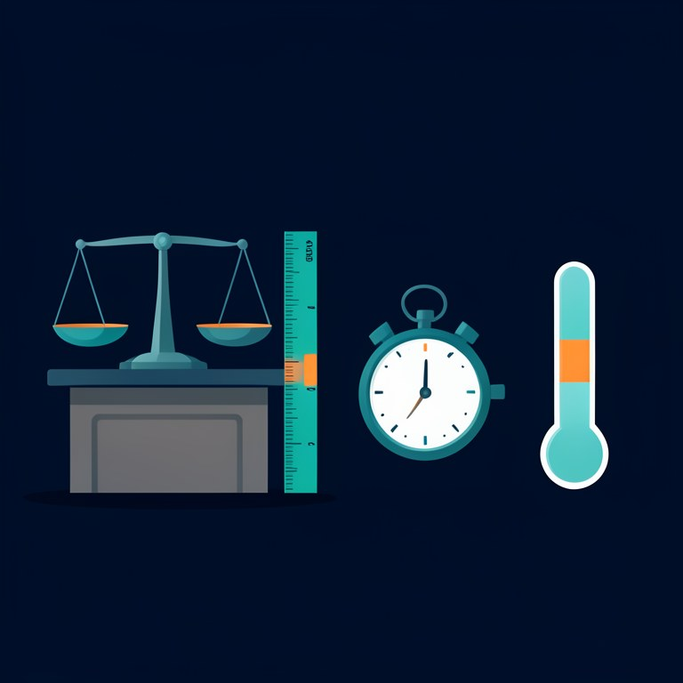

Illustrative image, generated with FLUX.2 [klein] 4B

## Four definitions

$$\text{demographic parity:}\quad P(\hat Y = 1 \mid A = a) = P(\hat Y = 1 \mid A = b)$$

$$\text{equal opportunity:}\quad P(\hat Y = 1 \mid Y = 1, A = a) = P(\hat Y = 1 \mid Y = 1, A = b)$$

| definition | equal across groups | in plain words |
| --- | --- | --- |
| demographic parity | selection rate $P(\hat Y = 1)$ | the same share flagged |
| equal opportunity | TPR | equally good at catching the sick |
| equalized odds | TPR and FPR | and equally many false alarms |
| calibration | $P(Y = 1 \mid \text{score})$ | “70 %” means the same in every group |

$A$ the sensitive attribute (here sex), $\hat Y$ the prediction, $Y$ the true outcome · Hardt, Price, Srebro (2016), [arXiv:1610.02413](https://arxiv.org/abs/1610.02413)

## Our model, by sex

| on the 76 test patients | computed as | women | men |
| --- | --- | --- | --- |
| patients (sick) |  | 26 (9) | 50 (26) |
| prevalence | sick / all | 9/26 = 0.346 | 26/50 = 0.520 |
| selection rate | flagged / all | 9/26 = 0.346 | 28/50 = 0.560 |
| TPR | flagged sick / all sick | 8/9 = 0.889 | 23/26 = 0.885 |
| FPR | flagged healthy / all healthy | 1/17 = 0.059 | 5/24 = 0.208 |
| PPV | sick among the flagged / flagged | 8/9 = 0.889 | 23/28 = 0.821 |

**Demographic parity** compares the *selection rate*: 0.560 − 0.346 = **0.214** — but the prevalences alone differ by 0.174, so even a perfect model would show most of this gap.  
**Equal opportunity** compares the *TPR*, the sick patients only: 0.889 vs 0.885 — satisfied.  
**Equalized odds** needs both *TPR* and *FPR* equal, so its gap is the larger of the two differences: max(0.004, 0.150) = **0.150** — men get three and a half times the false alarms.

Flagged = predicted sick ($\hat Y = 1$). Women: 9 flagged = 8 sick + 1 healthy; men: 28 flagged = 23 sick + 5 healthy. Every gap is men minus women, in absolute value.

## One split, or twenty?

[figure not shown]

Over 20 random splits the TPR of women has a median of **0.61**, of men **0.79**; men’s FPR is higher in **19 of 20**. The split we audited was an unusually kind one for women.

## Calibration by sex

[figure not shown]

- **On average** the model is calibrated in both groups: mean predicted risk 0.263 vs 0.263 observed in women, 0.542 vs 0.556 in men.
- **Bin by bin** it is not: a “low risk” (below 0.2) turned out sick in **10 %** of women but **22 %** of men.
- Both groups get **overconfident** scores at the top — 0.95 predicted, 0.75–0.85 observed.

A clinician who reads “low risk” for a man is wrong twice as often as for a woman.

## Intersections — the cells get tiny

|  | patients | sick | sick per test part (20 splits) |
| --- | --- | --- | --- |
| women < 55 | 40 | **2** | 0–2 |
| women ≥ 55 | 57 | 23 | 3–11 |
| men < 55 | 103 | 42 | 7–15 |
| men ≥ 55 | 103 | 72 | 13–23 |

A model can be fair for women and for the young separately and still be unfair to **young women** — and with **2** sick young women in the whole data set, nobody can tell.

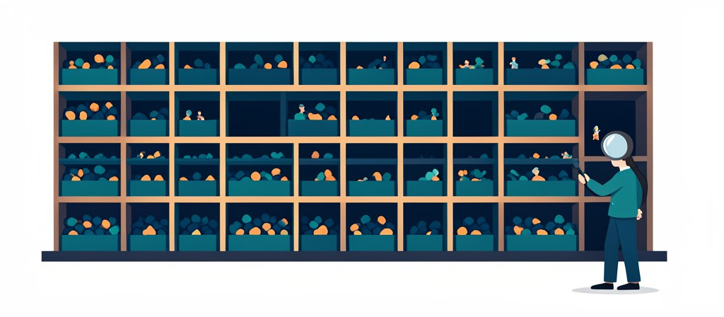

Illustrative image, generated with FLUX.2 [klein] 4B

Kearns, Neel, Roth, Wu (2018), *Preventing Fairness Gerrymandering*, [arXiv:1711.05144](https://arxiv.org/abs/1711.05144)

## You cannot have them all

$$\mathrm{FPR} = \frac{p}{1 - p}\cdot\frac{1 - \mathrm{PPV}}{\mathrm{PPV}}\cdot(1 - \mathrm{FNR})$$

- $p$ — the prevalence in the group; FNR — false negative rate (miss rate), $1 - \mathrm{TPR}$.
- Equal PPV across groups is **predictive parity** — “a flag means the same in every group”, the thresholded cousin of calibration.
- Hold PPV and FNR equal across two groups, and the identity **forces** their FPRs apart the moment their prevalences differ — unless PPV = 1, no false alarms at all.

**With our prevalences:** PPV = 0.70 and FNR = 0.30 in both groups. Women, $p = 0.258$: $\mathrm{FPR} = \tfrac{0.258}{0.742}\cdot\tfrac{0.30}{0.70}\cdot 0.70 = 0.104$. Men, $p = 0.553$: $\mathrm{FPR} = 0.372$.

Chouldechova (2017), [arXiv:1703.00056](https://arxiv.org/abs/1703.00056) · Kleinberg, Mullainathan, Raghavan (2016), [arXiv:1609.05807](https://arxiv.org/abs/1609.05807)

## The proof, in one picture

[figure not shown]

- The curve is the identity, not a fit.
- The two dots are the prevalences of **our** data.

So which definition matters **for this decision**? A clinical call, made before the audit — not after you see which one your model passes.

## Demographic parity — strengths and pitfalls

Use it when

- A **resource** is allocated (outreach, care programmes) and the labels themselves are suspected of bias — as the cost label of Obermeyer et al.
- You have **no outcomes yet**: it needs only the predictions, so it can be monitored from the first day of deployment.
- One number per group, easy to explain.

Watch out

- It **ignores the truth**: with 26 % of women and 55 % of men sick, equal shares flagged means missed sick men or flagged healthy women.
- Our model’s gap of 0.214 is mostly the prevalence gap of 0.174.
- A useless model passes it — flag everyone, or flag at random.
- Enforced by per-group thresholds on our model, it cut the men’s TPR to 0.64.

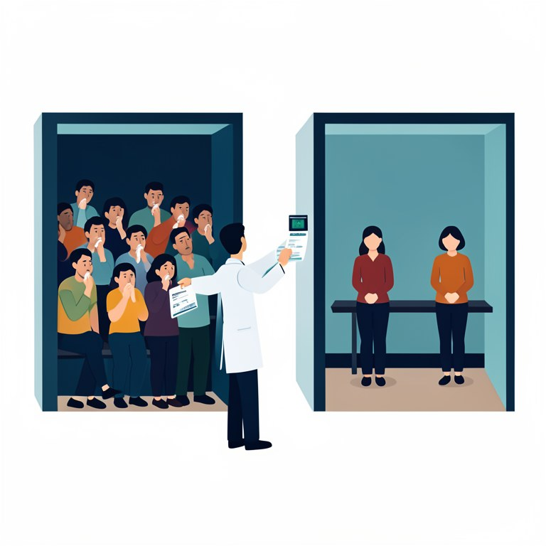

Illustrative image, generated with FLUX.2 [klein] 4B

Demographic parity asks “are the groups flagged equally?” — in medicine the honest answer is usually “they should not be”.

## Equal opportunity — strengths and pitfalls

Use it when

- **Missing a sick patient** is the costly error — screening, triage, referral for a work-up.
- It respects the prevalences: it compares only the sick with the sick.
- It is the first thing a clinician asks: “does it catch the disease in women as well as in men?”

Watch out

- **False alarms do not count**: our model passed it (0.889 vs 0.885) with men’s FPR three and a half times the women’s.
- It needs **labels** — and the labels can be the biased part (cost for need).
- It rests on the **sick** patients of the smaller group: 9 sick women, one prediction = 11 points.

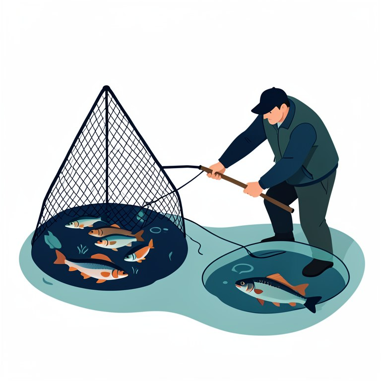

Illustrative image, generated with FLUX.2 [klein] 4B

Equal opportunity is the natural default for a diagnostic model — as long as the group has enough sick patients to measure it.

## Equalized odds — strengths and pitfalls

Use it when

- **Both errors** have a cost: a missed diagnosis, and an invasive or expensive follow-up after a false alarm.
- The groups should face the **same error rates**, whatever their prevalence.
- The strictest of the error-rate criteria: it catches the FPR gap that equal opportunity missed.

Watch out

- With different prevalences it **contradicts calibration and equal PPV** — the theorem.
- Reaching it usually means **per-group thresholds and coin flips** (block 3).
- It costs accuracy: 0.842 → 0.822 on our held-out split, averaged over the coin flips.
- Two rates per group, each from a small count — twice the noise.

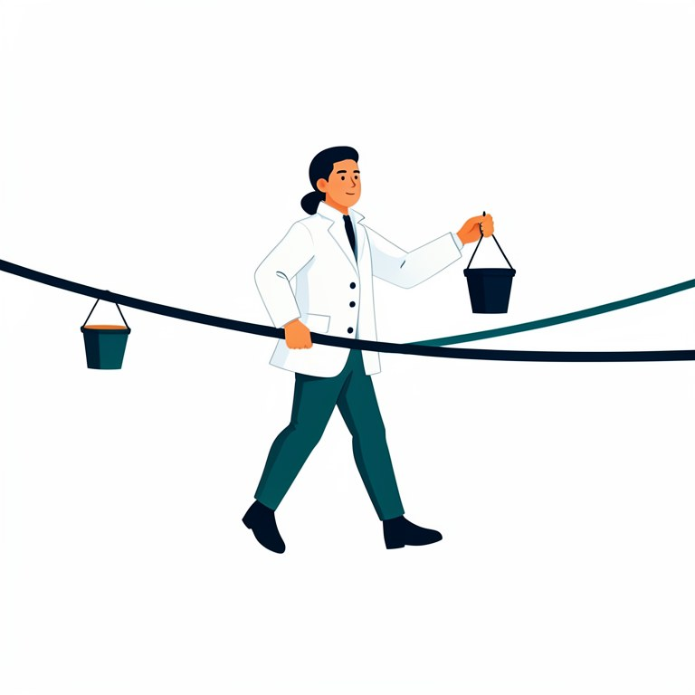

Illustrative image, generated with FLUX.2 [klein] 4B

Equalized odds equalizes the errors — and pays for it in calibration, accuracy, or both.

## Calibration — strengths and pitfalls

Use it when

- The score is **read as a risk** by a clinician, and the threshold is chosen later, per decision.
- It is what clinical risk scores promise: “a 20 % risk” means 20 % in every group.
- Our model meets it **on average** in both sexes.

Watch out

- It is **compatible with unequal error rates** — our calibrated model had men’s FPR three and a half times the women’s.
- Averages hide bins: the “low risk” bin, 10 % sick women vs 22 % sick men.
- It needs **many patients per bin**; one test part of 26 women cannot fill five bins.
- Calibrated on yesterday’s patients is not calibrated on tomorrow’s.

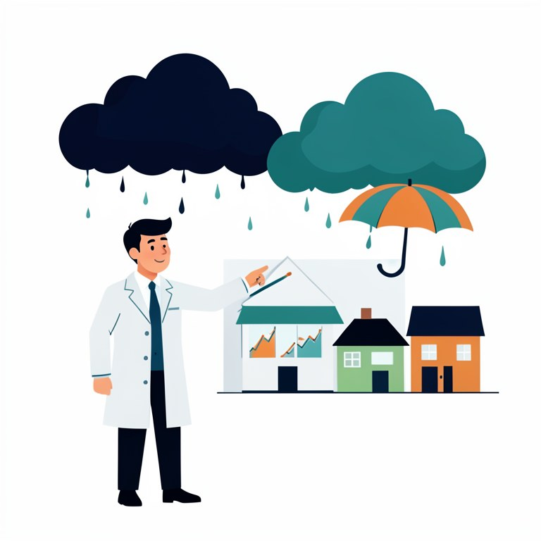

Illustrative image, generated with FLUX.2 [klein] 4B

Calibration makes the number honest — it does not make the decision fair.

## 3 · What you can do about it

> Every fix moves the error somewhere else.

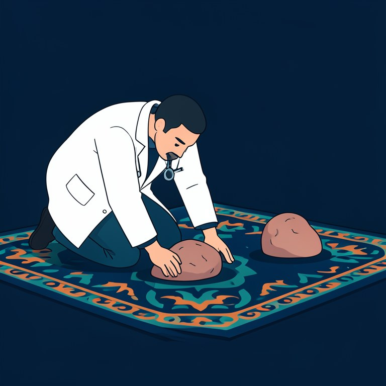

Illustrative image, generated with FLUX.2 [klein] 4B

## Three points of intervention

**pre-processing**

reweigh or resample the training data

→

**in-processing**

a fairness constraint in the training objective

→

**post-processing**

per-group decision thresholds

| stage | touches | cost |
| --- | --- | --- |
| pre-processing | the training data | retraining |
| in-processing | the training objective | a new training method |
| post-processing | the thresholds, after training | a calibration split — the cheapest to try |

[Fairlearn User Guide — mitigation](https://fairlearn.org/main/user_guide/mitigation/index.html) · [AIF360](https://aif360.readthedocs.io/)

AIF360 — AI Fairness 360, an open-source toolkit started by IBM

## “Just drop the attribute”

[figure not shown]

- Retrained **without `sex`**, on the same twenty splits: the gaps shrink — and stay.
- The other twelve features predict sex with an AUC of **0.72**: a normal thallium scan (`thal`) in 84 % of women, 42 % of men.
- And sex is a **real risk factor** here — deleting it also deletes medicine.

“Fairness through unawareness” hides the attribute from the model, not from the data: the gaps shrank, they did not go away.

## Pre-processing: reweighing

| weight | sick | healthy |
| --- | --- | --- |
| women | **2.39** | 0.67 |
| men | 0.79 | 1.28 |

$$w(a, y) = \frac{P(A = a)\,P(Y = y)}{P(A = a,\ Y = y)}$$

- Every training patient gets a weight so that, **in the weighted data**, sex and the disease are independent.
- The rare cell — sick women — counts 2.4 times, healthy men 1.3 times.
- On our held-out test part: demographic-parity gap 0.468 → **0.390**, equalized-odds gap 0.333 → **0.283**, accuracy 0.842 → **0.803**.

Reweighing changes what the model learns from, not how it decides — a small step towards parity, paid for in accuracy.

Kamiran, Calders (2012), *Data preprocessing techniques for classification without discrimination*, Knowl Inf Syst 33:1 · our model: [`studies.py`](https://github.com/tomasvicar/AUI-public/blob/master/lectures/bias-fairness/code/studies.py)

## Pre-processing — strengths and pitfalls

Use it when

- The imbalance is **in the data**: a group or a group-and-label cell is rare.
- Any learner that takes sample weights; the model and its use stay the same.
- The method needs no group input **at prediction time** (our model still reads `sex` as a feature).

Watch out

- On our model it moved the gaps only a little (0.468 → 0.390) and cost 4 points of accuracy.
- A model that memorizes its training data can largely ignore the weights.
- It aims at independence of label and group — not at equal error rates.
- It **cannot fix a wrong label**: reweighing cost does not make it need.

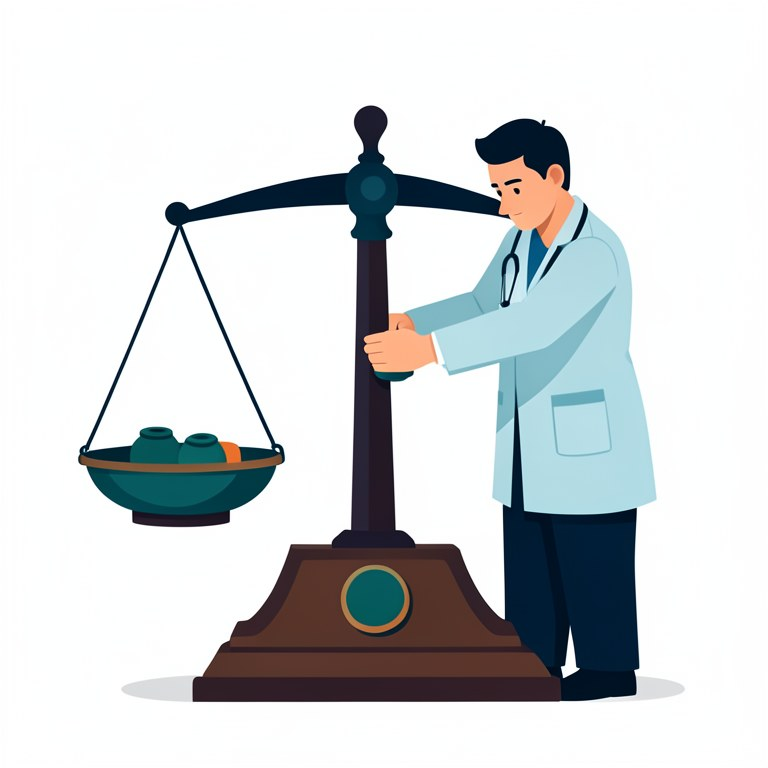

Illustrative image, generated with FLUX.2 [klein] 4B

Reweighing is cheap and transparent — and weak against a flexible model.

## In-processing: a constraint in training

- `fairlearn`’s **ExponentiatedGradient** retrains the model many times with changing weights until the constraint holds — on the **training data**.
- With **equalized odds**: the result is **identical** to the unmitigated model, accuracy 0.842, gap 0.333.
- Why? On its own training data XGBoost is **perfect** — TPR 1, FPR 0 for women and for men. The constraint already holds where it is checked.
- With **demographic parity**: the gap closes (0.097) — at accuracy **0.712**, women’s FPR **0.46** (means over 200 draws of its randomized prediction).

A fairness constraint enforced on training data is only as good as the training error is honest — a model that memorizes passes every constraint.

Agarwal, Beygelzimer, Dudík, Langford, Wallach (2018), *A Reductions Approach to Fair Classification*, [arXiv:1803.02453](https://arxiv.org/abs/1803.02453)

## In-processing — strengths and pitfalls

Use it when

- You train the model yourself and want **one model** that meets the constraint by design.
- The trade-off between accuracy and the constraint is a **parameter** you can set.
- The method needs no group input at prediction time.

Watch out

- The constraint is enforced on **training data**: XGBoost was perfect there, so equalized odds changed nothing.
- When it does bite it can bite hard: demographic parity, accuracy 0.712.
- The result is a **randomized mixture** of many models, slow to train and hard to explain.

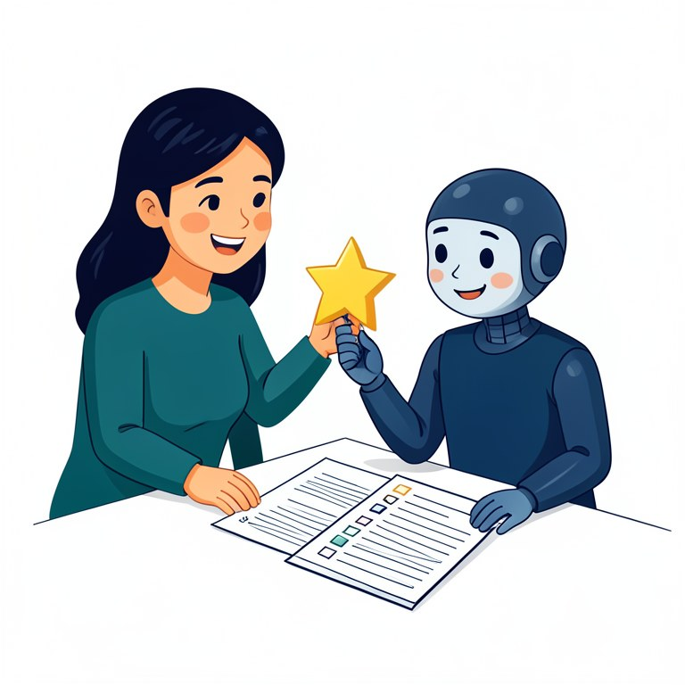

Illustrative image, generated with FLUX.2 [klein] 4B

In-processing is the principled place for fairness — and the place where an overfitted model fools it most easily.

## Post-processing on our model

[figure not shown]

`fairlearn`’s ThresholdOptimizer; split 50 / 25 / 25 % — thresholds fitted on the calibration part, all numbers on the test part (27 women, 7 of them sick; 49 men); one draw of the randomized rule (`random_state=42`).

## Equalized odds, geometrically

[figure not shown]

- Each group has its **own ROC curve**; one threshold puts women and men at different points (squares).
- Equalized odds needs **one point** — the same FPR and TPR — that both groups can reach.
- A coin flip between two thresholds reaches any point on the straight line joining them: the **convex hull**.
- The optimizer chose FPR 0.09, TPR 0.81 — for both groups **between** two thresholds. Hence the coin.

Hardt, Price, Srebro (2016), [arXiv:1610.02413](https://arxiv.org/abs/1610.02413) — the same picture is their figure of equalized odds · calibration part: 23 women (9 sick), 53 men (26 sick)

## A coin flip in the decision

[figure not shown]

For **15 of 76** test patients the equalized-odds rule draws lots: flagged with probability 0.42 (women) or 0.47 (men). A woman at risk 0.16 can be flagged; a man at 0.60 practically never is.

## Another draw, another verdict

[figure not shown]

The same thresholds, two draws: an equalized-odds gap of **0.043** on draw 42, **0.321** on draw 6 — almost the unmitigated 0.333. Over 200 draws the mean is **0.163**, and the women’s TPR falls below 0.714 in **123 of 200**.

## Per-group thresholds in the clinic

- **High-sensitivity troponin I**, the blood test for myocardial infarction: the upper reference limit is **16 ng/L for women, 34 ng/L for men**.
- With the new assay and these thresholds, myocardial infarction was diagnosed in **twice as many women** (11 % → 22 %); in men little changed (19 % → 21 %).
- The trial that followed, 48 282 patients in 10 hospitals: myocardial injury +42 % in women, +6 % in men — but the outcome of the women did not improve, and they still got less revascularization than men.

Group-specific thresholds can be the medically right choice — and equal metrics are not better outcomes: a diagnosis helps only if the treatment follows.

Shah et al. (2015), [BMJ 350:g7873](https://www.bmj.com/content/350/bmj.g7873) · Lee et al. (2019), *Sex-Specific Thresholds of High-Sensitivity Troponin in Patients With Suspected Acute Coronary Syndrome*, [J Am Coll Cardiol 74:2032](https://doi.org/10.1016/j.jacc.2019.07.082)

## Levelling down

- A gap can close in two ways: the worse-off group gets **better**, or the better-off group gets **worse**.
- On our model it was the second. On draw 42 the men’s TPR fell from 0.89 to 0.68 — **six more sick men missed** — while the women’s stayed at 0.714; **averaged over the draws** both fell: women 0.714 → **0.61**, men 0.89 → **0.73**.
- In medicine that is rarely what “fair” was meant to mean.

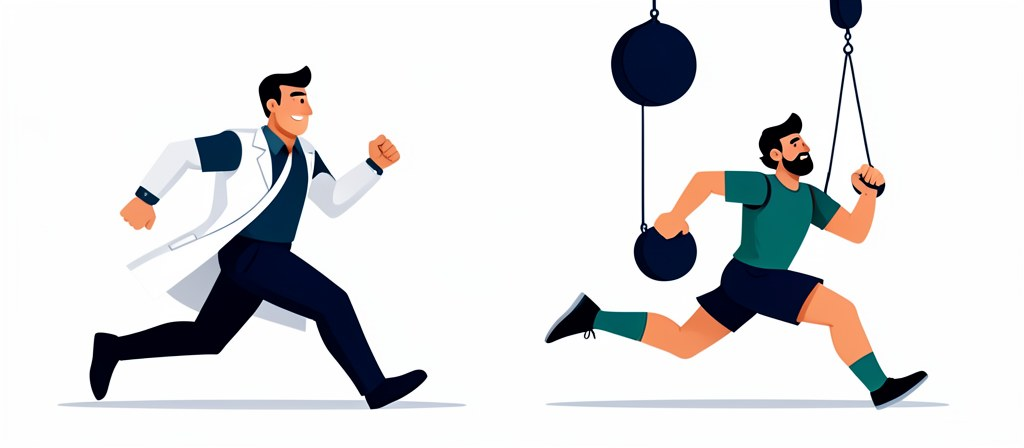

Illustrative image, generated with FLUX.2 [klein] 4B

**Levelling up** needs information, not thresholds: more and better data from the group the model serves worst — remember the women’s curve on *Who is in the training data?*

Mittelstadt, Wachter, Russell (2023), *The Unfairness of Fair Machine Learning: Levelling down and strict egalitarianism by default*, [arXiv:2302.02404](https://arxiv.org/abs/2302.02404) · Chen, Johansson, Sontag (2018), *Why Is My Classifier Discriminatory?*, [arXiv:1805.12002](https://arxiv.org/abs/1805.12002)

## Post-processing — strengths and pitfalls

Use it when

- The model is **already trained** — or bought, and you cannot touch it.
- It does narrow the gap: equalized-odds gap 0.333 → 0.163 on the held-out test part, on average over the draws.
- The cheapest to try; the thresholds are a few numbers to inspect.

Watch out

- It needs the group **at decision time** and treats the groups explicitly differently.
- **Coin flips**: 15 of 76 patients decided by chance — a gap of 0.04 on one draw, 0.32 on another.
- It needs a calibration split with enough patients per group — ours had 9 sick women.
- **Levelling down**: on average TPR 0.71 → 0.61 (women), 0.89 → 0.73 (men).

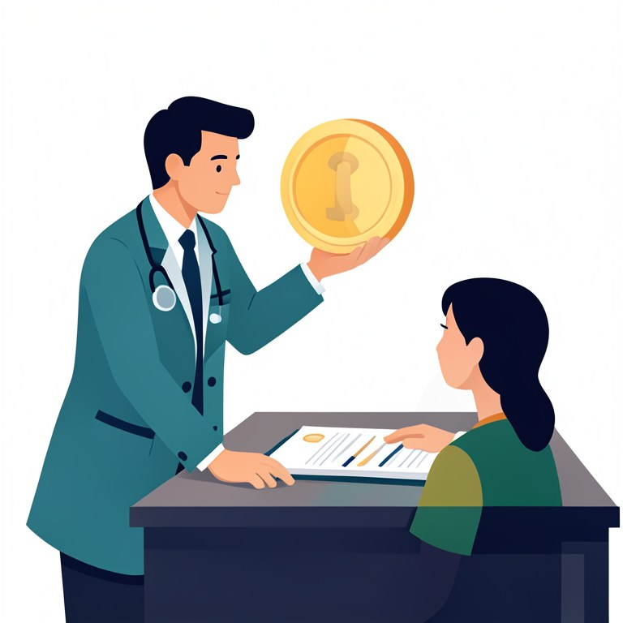

Illustrative image, generated with FLUX.2 [klein] 4B

Post-processing fixes the numbers fastest — check what it did to the patients.

## All three, side by side

[figure not shown]

Averaged over the draws, no approach helps the sick women cheaply: post-processing **lowers** their TPR (0.714 → 0.61 / 0.59), in-processing with parity raises it to 0.86 — by flagging **46 %** of the healthy women.

## Fair here, fair there?

- Chest X-ray, skin and eye models, chest X-rays from **six data sets** around the world: the models use **demographic shortcuts** for the diagnosis.
- Removing the shortcut by an algorithm closed the fairness gaps **in the original data** — a “locally optimal” model.
- In **new hospitals** that did not hold. The models fairest elsewhere were more often those that encoded demographics **least** to begin with.

A fairness audit is valid for the population it was done on. A model from another hospital is audited again on yours — and again when your patients change.

Yang, Zhang, Gichoya, Katabi, Ghassemi (2024), *The limits of fair medical imaging AI in real-world generalization*, [Nat Med 30:2838](https://doi.org/10.1038/s41591-024-03113-4)

## 4 · What to take home

> Fairness is a property of a decision, not of a model.

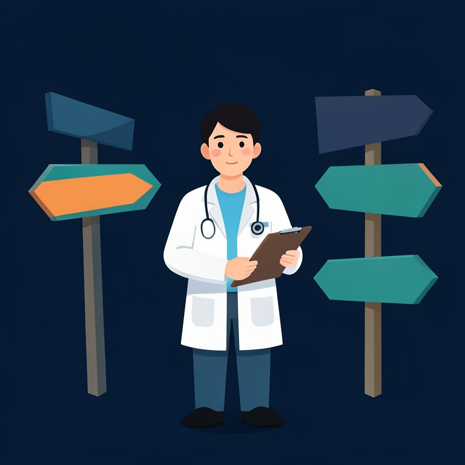

Illustrative image, generated with FLUX.2 [klein] 4B

## Takeaways

1. **Bias can enter without the attribute** — through a measurement, a proxy label, a coefficient, or who is missing from the data.
2. **Different definitions, different verdicts.** Our model passed calibration on average and equal opportunity on one split, and failed equalized odds.
3. **With different prevalences you cannot have them all** — choose the one that matches the clinical decision, before the audit.
4. **Small subgroups need their uncertainty.** One split said “no TPR gap”, twenty said “usually there is one”; 2 sick young women say nothing.
5. **Dropping the attribute does not remove it** — the other features carried sex with an AUC of 0.72.
6. **Every fix has a price** — sick patients of both groups missed, and coin flips that change the verdict from run to run; say who pays, prefer better data.

## Quick check

1. The pulse oximeter is accurate on average. Why can it still be biased?
2. The Obermeyer algorithm never saw race. Where did the bias come from?
3. What did the race coefficient of the 2009 eGFR equation do to a Black patient with failing kidneys?
4. Why did twenty splits give a different picture of the women’s TPR than one?
5. We retrained without `sex`. Why did the gaps not disappear?
6. Equal PPV and equal FNR for women and men — why must their FPRs then differ?
7. In-processing with equalized odds changed nothing on our model. Why?
8. Equalized-odds post-processing narrowed the gaps. Who paid for it — and why is one run not enough to say?

## The lab and the sources

### The lab — two parts

1. **Fairness audit** — the explainability model sliced by sex, the metrics by hand, twenty splits, then the model without `sex`.
2. **Mitigation, held out** — ThresholdOptimizer with equalized odds and with demographic parity, on a calibration split; one draw and two hundred.

[Lab page](https://github.com/tomasvicar/AUI-public/tree/master/labs/bias-fairness) · [`heart.py`](https://github.com/tomasvicar/AUI-public/blob/master/lectures/bias-fairness/code/heart.py), [`studies.py`](https://github.com/tomasvicar/AUI-public/blob/master/lectures/bias-fairness/code/studies.py) — every number of the lecture

### Reading

- Obermeyer et al. (2019), [*Science*](https://www.science.org/doi/10.1126/science.aax2342);
- Sjoding et al. (2020), [*NEJM*](https://www.nejm.org/doi/full/10.1056/NEJMc2029240);
- Inker et al. (2021), [*NEJM*](https://www.nejm.org/doi/full/10.1056/NEJMoa2102953);
- Seyyed-Kalantari et al. (2021), [*Nat Med*](https://www.nature.com/articles/s41591-021-01595-0);
- Hardt, Price, Srebro (2016), [arXiv:1610.02413](https://arxiv.org/abs/1610.02413);
- Chouldechova (2017), [arXiv:1703.00056](https://arxiv.org/abs/1703.00056);
- Mittelstadt et al. (2023), [arXiv:2302.02404](https://arxiv.org/abs/2302.02404);
- [Fairlearn User Guide](https://fairlearn.org/main/user_guide/index.html).